# (Dataset Exploration Title)

### Data Preprocessing

1- No Null values to be imputed

2- Start time & end time have no timestamp

3- No duplicates

4- I would change the duration_sec column to be in minutes so we have better and smaller numbers

5- Add 2 columns for the day and the month from start_time column so we can use them later in the analysis

6- Convert month & day column to categorical data

```python
#Changing start time and end time to datetime
df.start_time = pd.to_datetime(df.start_time)
df.end_time = pd.to_datetime(df.end_time)
```

```python
type(df.start_time[0])
```

```
pandas._libs.tslibs.timestamps.Timestamp
```

```python
type(df.end_time[0])
```

```
pandas._libs.tslibs.timestamps.Timestamp
```

```python
#checking the number of user types
df.user_type.unique()
```

```
array(['Customer', 'Subscriber'], dtype=object)
```

```python
#changing the duration_sec to be in minutes
df.duration_sec = df.duration_sec/60
df.rename({'duration_sec': 'duration'}, axis=1, inplace=True)
df.head()
```

|  | duration | start_time | end_time | start_station_id | start_station_name | start_station_latitude | start_station_longitude | end_station_id | end_station_name | end_station_latitude | end_station_longitude | bike_id | user_type |
| --- | --- | --- | --- | --- | --- | --- | --- | --- | --- | --- | --- | --- | --- |
| 0 | 1335.166667 | 2017-12-31 16:57:39.654 | 2018-01-01 15:12:50.245 | 74 | Laguna St at Hayes St | 37.776435 | -122.426244 | 43 | San Francisco Public Library (Grove St at Hyde... | 37.778768 | -122.415929 | 96 | Customer |
| 1 | 1313.333333 | 2017-12-31 15:56:34.842 | 2018-01-01 13:49:55.617 | 284 | Yerba Buena Center for the Arts (Howard St at ... | 37.784872 | -122.400876 | 96 | Dolores St at 15th St | 37.766210 | -122.426614 | 88 | Customer |
| 2 | 762.800000 | 2017-12-31 22:45:48.411 | 2018-01-01 11:28:36.883 | 245 | Downtown Berkeley BART | 37.870348 | -122.267764 | 245 | Downtown Berkeley BART | 37.870348 | -122.267764 | 1094 | Customer |
| 3 | 1036.200000 | 2017-12-31 17:31:10.636 | 2018-01-01 10:47:23.531 | 60 | 8th St at Ringold St | 37.774520 | -122.409449 | 5 | Powell St BART Station (Market St at 5th St) | 37.783899 | -122.408445 | 2831 | Customer |
| 4 | 726.716667 | 2017-12-31 14:23:14.001 | 2018-01-01 02:29:57.571 | 239 | Bancroft Way at Telegraph Ave | 37.868813 | -122.258764 | 247 | Fulton St at Bancroft Way | 37.867789 | -122.265896 | 3167 | Subscriber |

```python
#round up to 2 decimall places
df.duration = df.duration.round(decimals=2)
```

```python
df.duration
```

```
0         1335.17
1         1313.33
2          762.80
3         1036.20
4          726.72
           ...
519695       7.25
519696       7.18
519697       7.07
519698       6.10
519699       3.13
Name: duration, Length: 519700, dtype: float64
```

```python
#Creating day and month columns
df['month'] = pd.DatetimeIndex(df['start_time']).month
df['day'] = pd.DatetimeIndex(df['start_time']).weekday_name
```

```python
df.head()
```

|  | duration | start_time | end_time | start_station_id | start_station_name | start_station_latitude | start_station_longitude | end_station_id | end_station_name | end_station_latitude | end_station_longitude | bike_id | user_type | month | day |
| --- | --- | --- | --- | --- | --- | --- | --- | --- | --- | --- | --- | --- | --- | --- | --- |
| 0 | 1335.17 | 2017-12-31 16:57:39.654 | 2018-01-01 15:12:50.245 | 74 | Laguna St at Hayes St | 37.776435 | -122.426244 | 43 | San Francisco Public Library (Grove St at Hyde... | 37.778768 | -122.415929 | 96 | Customer | 12 | Sunday |
| 1 | 1313.33 | 2017-12-31 15:56:34.842 | 2018-01-01 13:49:55.617 | 284 | Yerba Buena Center for the Arts (Howard St at ... | 37.784872 | -122.400876 | 96 | Dolores St at 15th St | 37.766210 | -122.426614 | 88 | Customer | 12 | Sunday |
| 2 | 762.80 | 2017-12-31 22:45:48.411 | 2018-01-01 11:28:36.883 | 245 | Downtown Berkeley BART | 37.870348 | -122.267764 | 245 | Downtown Berkeley BART | 37.870348 | -122.267764 | 1094 | Customer | 12 | Sunday |
| 3 | 1036.20 | 2017-12-31 17:31:10.636 | 2018-01-01 10:47:23.531 | 60 | 8th St at Ringold St | 37.774520 | -122.409449 | 5 | Powell St BART Station (Market St at 5th St) | 37.783899 | -122.408445 | 2831 | Customer | 12 | Sunday |
| 4 | 726.72 | 2017-12-31 14:23:14.001 | 2018-01-01 02:29:57.571 | 239 | Bancroft Way at Telegraph Ave | 37.868813 | -122.258764 | 247 | Fulton St at Bancroft Way | 37.867789 | -122.265896 | 3167 | Subscriber | 12 | Sunday |

```python
df.month.unique()
```

```
array([12, 11, 10,  9,  8,  7,  6], dtype=int64)
```

```python
#converting months column to the month name
months = {6: 'June', 7: 'July', 8: 'August', 9: 'September', 10: 'October', 11: 'November', 12: 'December'}
df.month = df.month.map(months)
df.head()
```

|  | duration | start_time | end_time | start_station_id | start_station_name | start_station_latitude | start_station_longitude | end_station_id | end_station_name | end_station_latitude | end_station_longitude | bike_id | user_type | month | day |
| --- | --- | --- | --- | --- | --- | --- | --- | --- | --- | --- | --- | --- | --- | --- | --- |
| 0 | 1335.17 | 2017-12-31 16:57:39.654 | 2018-01-01 15:12:50.245 | 74 | Laguna St at Hayes St | 37.776435 | -122.426244 | 43 | San Francisco Public Library (Grove St at Hyde... | 37.778768 | -122.415929 | 96 | Customer | December | Sunday |
| 1 | 1313.33 | 2017-12-31 15:56:34.842 | 2018-01-01 13:49:55.617 | 284 | Yerba Buena Center for the Arts (Howard St at ... | 37.784872 | -122.400876 | 96 | Dolores St at 15th St | 37.766210 | -122.426614 | 88 | Customer | December | Sunday |
| 2 | 762.80 | 2017-12-31 22:45:48.411 | 2018-01-01 11:28:36.883 | 245 | Downtown Berkeley BART | 37.870348 | -122.267764 | 245 | Downtown Berkeley BART | 37.870348 | -122.267764 | 1094 | Customer | December | Sunday |
| 3 | 1036.20 | 2017-12-31 17:31:10.636 | 2018-01-01 10:47:23.531 | 60 | 8th St at Ringold St | 37.774520 | -122.409449 | 5 | Powell St BART Station (Market St at 5th St) | 37.783899 | -122.408445 | 2831 | Customer | December | Sunday |
| 4 | 726.72 | 2017-12-31 14:23:14.001 | 2018-01-01 02:29:57.571 | 239 | Bancroft Way at Telegraph Ave | 37.868813 | -122.258764 | 247 | Fulton St at Bancroft Way | 37.867789 | -122.265896 | 3167 | Subscriber | December | Sunday |

```python
#converting month and day to categorical data types
months = ['June', 'July', 'August', 'September', 'October', 'November', 'December']
days = ['Monday', 'Tuesday', 'Wednesday', 'Thursday', 'Friday', 'Saturday', 'Sunday']
ordered_months = pd.api.types.CategoricalDtype(ordered=True, categories=months)
ordered_days = pd.api.types.CategoricalDtype(ordered=True, categories=days)
df.month = df.month.astype(ordered_months)
df.day = df.day.astype(ordered_days)
```

```python
df.shape
```

```
(519700, 15)
```

```python
df.info()
```

```
<class 'pandas.core.frame.DataFrame'>
RangeIndex: 519700 entries, 0 to 519699
Data columns (total 15 columns):
duration                   519700 non-null float64
start_time                 519700 non-null datetime64[ns]
end_time                   519700 non-null datetime64[ns]
start_station_id           519700 non-null int64
start_station_name         519700 non-null object
start_station_latitude     519700 non-null float64
start_station_longitude    519700 non-null float64
end_station_id             519700 non-null int64
end_station_name           519700 non-null object
end_station_latitude       519700 non-null float64
end_station_longitude      519700 non-null float64
bike_id                    519700 non-null int64
user_type                  519700 non-null object
month                      519700 non-null category
day                        519700 non-null category
dtypes: category(2), datetime64[ns](2), float64(5), int64(3), object(3)
memory usage: 52.5+ MB
```

```python
df.head()
```

|  | duration | start_time | end_time | start_station_id | start_station_name | start_station_latitude | start_station_longitude | end_station_id | end_station_name | end_station_latitude | end_station_longitude | bike_id | user_type | month | day |
| --- | --- | --- | --- | --- | --- | --- | --- | --- | --- | --- | --- | --- | --- | --- | --- |
| 0 | 1335.17 | 2017-12-31 16:57:39.654 | 2018-01-01 15:12:50.245 | 74 | Laguna St at Hayes St | 37.776435 | -122.426244 | 43 | San Francisco Public Library (Grove St at Hyde... | 37.778768 | -122.415929 | 96 | Customer | December | Sunday |
| 1 | 1313.33 | 2017-12-31 15:56:34.842 | 2018-01-01 13:49:55.617 | 284 | Yerba Buena Center for the Arts (Howard St at ... | 37.784872 | -122.400876 | 96 | Dolores St at 15th St | 37.766210 | -122.426614 | 88 | Customer | December | Sunday |
| 2 | 762.80 | 2017-12-31 22:45:48.411 | 2018-01-01 11:28:36.883 | 245 | Downtown Berkeley BART | 37.870348 | -122.267764 | 245 | Downtown Berkeley BART | 37.870348 | -122.267764 | 1094 | Customer | December | Sunday |
| 3 | 1036.20 | 2017-12-31 17:31:10.636 | 2018-01-01 10:47:23.531 | 60 | 8th St at Ringold St | 37.774520 | -122.409449 | 5 | Powell St BART Station (Market St at 5th St) | 37.783899 | -122.408445 | 2831 | Customer | December | Sunday |
| 4 | 726.72 | 2017-12-31 14:23:14.001 | 2018-01-01 02:29:57.571 | 239 | Bancroft Way at Telegraph Ave | 37.868813 | -122.258764 | 247 | Fulton St at Bancroft Way | 37.867789 | -122.265896 | 3167 | Subscriber | December | Sunday |

```python
df.describe()
```

|  | duration | start_station_id | start_station_latitude | start_station_longitude | end_station_id | end_station_latitude | end_station_longitude | bike_id |
| --- | --- | --- | --- | --- | --- | --- | --- | --- |
| count | 519700.000000 | 519700.000000 | 519700.000000 | 519700.000000 | 519700.000000 | 519700.000000 | 519700.000000 | 519700.000000 |
| mean | 18.316829 | 95.034245 | 37.771653 | -122.363927 | 92.184041 | 37.771844 | -122.363236 | 1672.533079 |
| std | 57.402448 | 86.083078 | 0.086305 | 0.105573 | 84.969491 | 0.086224 | 0.105122 | 971.356959 |
| min | 1.020000 | 3.000000 | 37.317298 | -122.444293 | 3.000000 | 37.317298 | -122.444293 | 10.000000 |
| 25% | 6.370000 | 24.000000 | 37.773492 | -122.411726 | 23.000000 | 37.774520 | -122.410345 | 787.000000 |
| 50% | 9.930000 | 67.000000 | 37.783521 | -122.398870 | 66.000000 | 37.783830 | -122.398525 | 1728.500000 |
| 75% | 15.630000 | 139.000000 | 37.795392 | -122.391034 | 134.000000 | 37.795392 | -122.391034 | 2520.000000 |
| max | 1439.480000 | 340.000000 | 37.880222 | -121.874119 | 340.000000 | 37.880222 | -121.874119 | 3733.000000 |

### What is the structure of your dataset?

> The dataset consists of 519700 entries (rows) and 15 features (columns)

### What is/are the main feature(s) of interest in your dataset?

> duration_sec, 'start_time', 'end_time', 'start_station_id', 'end_station_id', 'bike_id', 'user_type', 'day', 'month'

### What features in the dataset do you think will help support your investigation into your feature(s) of interest?

> duration_sec, 'start_time', 'end_time', 'start_station_id', 'end_station_id', 'day', 'month'

## Univariate Exploration

**At first I would take a look at the distribution of duration**

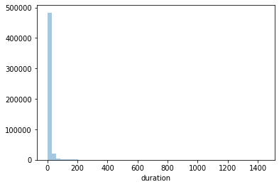

```python
sns.distplot(df.duration, kde=False);
```

```python
#since that doesen't show us much, let's check the statistical values of that column
df.duration.describe()
```

```
count    519700.000000
mean         18.316829
std          57.402448
min           1.020000
25%           6.370000
50%           9.930000
75%          15.630000
max        1439.480000
Name: duration, dtype: float64
```

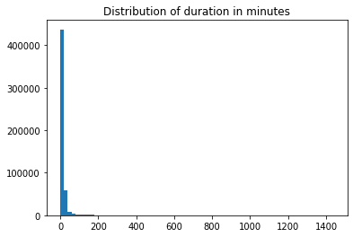

```python
bins = np.arange(0, df.duration.max()+20, 20)
plt.hist(df.duration, bins=bins)
plt.title('Distribution of duration in minutes');
```

From the plot, it is clear that the majority of the data lies between 0 and 200 with a pretty long skew to the right. I would try the exponential distribution as it might show us more details.

```python
np.log10(df.duration.describe())
```

```
count    5.715753
mean     1.262850
std      1.758930
min      0.008600
25%      0.804139
50%      0.996949
75%      1.193959
max      3.158206
Name: duration, dtype: float64
```

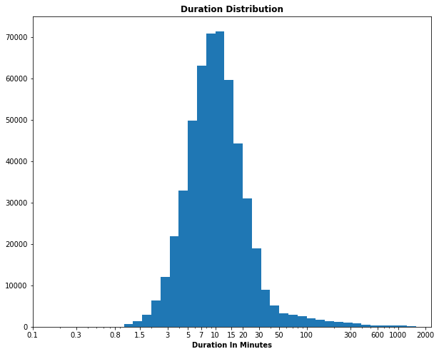

```python
#Creating a figure
plt.figure(figsize=(10, 8))
#Setting the bins and the bin size according to np.log10(df.duration.max())
bins = 10 ** np.arange(0, 3.158 + 0.1, 0.1)
ticks = [0.1, 0.8, 1.5, 0.3, 3, 5, 7, 10, 15, 20, 30, 50, 100, 300, 600, 1000, 2000]
labels = [str(i) for i in ticks]
#plotting the histogram
plt.hist(df.duration, bins=bins)
#setting the x_scale to logarithmic
plt.xscale('log')
plt.xlabel('Duration In Minutes', weight='bold')
plt.title('Duration Distribution', weight='bold')
plt.xticks(ticks, labels);
```

So, this plot is more informative as we can see that the duration values seem to be normally distributed with some values over 200 making a right tail.

It is also clear that durations mostly are between 3 and 30 minutes as most of the points lie between those boundaries.

values over 1000 make no sense as it is hard for one rider to ride the bike for a whole day!! and these values are mostley outliers.

**Moving on to another feature**

I would check the changing number of rides through days and months

```python
#Setting the color
color = sns.color_palette()[0]
```

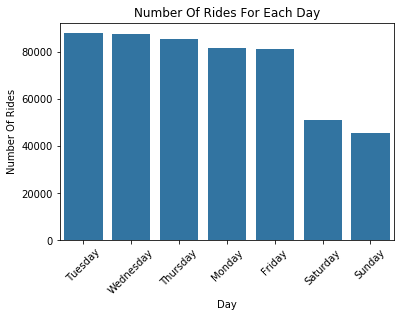

```python
#viewing the number of rides for each day of the week
sns.countplot(df.day, order=df.day.value_counts(ascending=False).index, color=color)
plt.xticks(rotation=45)
plt.xlabel('Day')
plt.ylabel('Number of rides'.title())
plt.title('number of rides for each day'.title());
```

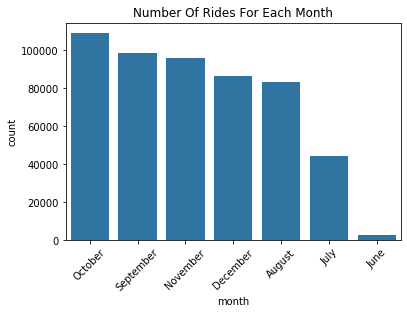

```python
#number of rides for each month
sns.countplot(df.month, order=df.month.value_counts(ascending=False).index, color=color)
plt.xticks(rotation=45)
plt.title('number of rides for each month'.title());
```

From the above visualizations we can clearly see that Tuesday and Wednesday are the day with the most rides then Thursday, Monday and Friday have slightly less rides and Saturday and Sunday are the days with the lowest number of rides.

On the other hand, when it comes to number of rides for each month, it’s also clear that October is the month with the most rides and June is by far the month with the lowest number of rides.

**Let's check the user_type column**

```python
df.user_type.unique()
```

```
array(['Customer', 'Subscriber'], dtype=object)
```

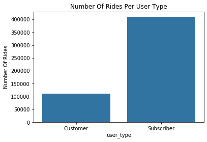

```python
sns.countplot(df.user_type, color=color)
plt.title('number of rides per user type'.title())
plt.ylabel('number of rides'.title());
```

subscribers have far more rides than Customers

**Checking the starting station**

```python
df.start_station_name.nunique()
```

```
272
```

```python
df.start_station_name.value_counts(ascending=False).values
```

```
array([15187, 13664, 12546, 12055, 11960, 11334, 10956, 10142,  9926,
        9347,  7987,  7649,  6605,  6414,  6223,  5980,  5785,  5732,
        5609,  5558,  5497,  4842,  4798,  4795,  4750,  4656,  4648,
        4600,  4511,  4269,  4193,  4185,  4107,  4022,  3929,  3883,
        3813,  3811,  3474,  3393,  3386,  3318,  3245,  3144,  3143,
        3057,  3053,  3046,  3021,  3000,  2957,  2935,  2933,  2851,
        2777,  2731,  2692,  2670,  2658,  2636,  2608,  2571,  2543,
        2528,  2516,  2472,  2467,  2444,  2443,  2311,  2310,  2303,
        2277,  2266,  2255,  2249,  2196,  2170,  2147,  2106,  2080,
        2055,  2047,  2038,  2004,  2001,  1992,  1981,  1979,  1911,
        1886,  1858,  1761,  1760,  1675,  1667,  1665,  1648,  1642,
        1624,  1614,  1610,  1609,  1607,  1605,  1577,  1569,  1567,
        1551,  1524,  1520,  1508,  1494,  1493,  1491,  1481,  1474,
        1463,  1449,  1441,  1436,  1416,  1407,  1404,  1400,  1295,
        1270,  1262,  1249,  1245,  1241,  1234,  1223,  1173,  1170,
```

[output cut: 16 more lines]

We have 272 starting stations, which is too much to plot. so instead we can take only the stations that were used 10000 or more for simplicity and they are the top 8 stations.

```python
df.start_station_name.value_counts(ascending=False)[:8].index
```

```
Index(['San Francisco Ferry Building (Harry Bridges Plaza)',
       'The Embarcadero at Sansome St',
       'San Francisco Caltrain (Townsend St at 4th St)',
       'San Francisco Caltrain Station 2  (Townsend St at 4th St)',
       'Market St at 10th St',
       'Montgomery St BART Station (Market St at 2nd St)',
       'Berry St at 4th St', 'Powell St BART Station (Market St at 4th St)'],
      dtype='object')
```

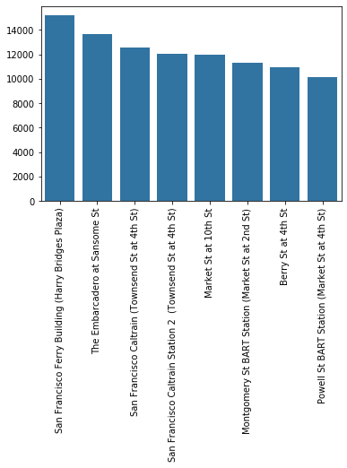

```python
top_stations = df.start_station_name.value_counts(ascending=False)[:8]
sns.barplot(x=top_stations.index, y=top_stations.values, color=color)
plt.xticks(rotation=90);
```

It will look even better if we exchanged the positions of x and y axes

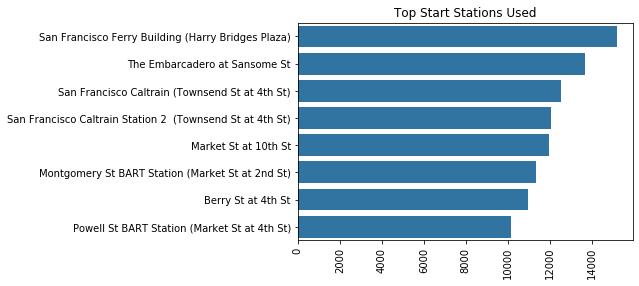

```python
sns.barplot(x=top_stations.values, y=top_stations.index, color=color)
plt.xticks(rotation=90)
plt.title('top start stations used'.title()) ;
```

The station 'San Francisco Ferry Building (Harry Bridges Plaza)' Is the one that has been used the most as the start station

### Discuss the distribution(s) of your variable(s) of interest. Were there any unusual points? Did you need to perform any transformations?

1- The values seemed normally distributed except of some values above 300 making a skewed tail to the right.

2- As for the number of rides per day, it was obvious that weekdays had more rides than weekend with Tuesday and Wednesday with highest number of rides.

3- October was the month with the highest number of rides.

4- Most users were subscribers not customers

5- The station 'San Francisco Ferry Building (Harry Bridges Plaza)’ has been used the most as starting station

### Of the features you investigated, were there any unusual distributions? Did you perform any operations on the data to tidy, adjust, or change the form of the data? If so, why did you do this?

1- I had to use logarithmic scale on the duration column as the distribution of the values wasn’t quite clear

2- Weekdays have more rides than weekends, so from that we can conclude that a good number of people would rather use the bikes to go to work or after worktime than using it during the weekend.

3- It was surprising to found the month of June having so little number of rides comparing to the other months putting in mind that it’s the beginning of the summer and people could be riding more.

## Bivariate Exploration

> In this section, investigate relationships between pairs of variables in your data. Make sure the variables that you cover here have been introduced in some fashion in the previous section (univariate exploration).

```python
df.head()
```

|  | duration | start_time | end_time | start_station_id | start_station_name | start_station_latitude | start_station_longitude | end_station_id | end_station_name | end_station_latitude | end_station_longitude | bike_id | user_type | month | day |
| --- | --- | --- | --- | --- | --- | --- | --- | --- | --- | --- | --- | --- | --- | --- | --- |
| 0 | 1335.17 | 2017-12-31 16:57:39.654 | 2018-01-01 15:12:50.245 | 74 | Laguna St at Hayes St | 37.776435 | -122.426244 | 43 | San Francisco Public Library (Grove St at Hyde... | 37.778768 | -122.415929 | 96 | Customer | December | Sunday |
| 1 | 1313.33 | 2017-12-31 15:56:34.842 | 2018-01-01 13:49:55.617 | 284 | Yerba Buena Center for the Arts (Howard St at ... | 37.784872 | -122.400876 | 96 | Dolores St at 15th St | 37.766210 | -122.426614 | 88 | Customer | December | Sunday |
| 2 | 762.80 | 2017-12-31 22:45:48.411 | 2018-01-01 11:28:36.883 | 245 | Downtown Berkeley BART | 37.870348 | -122.267764 | 245 | Downtown Berkeley BART | 37.870348 | -122.267764 | 1094 | Customer | December | Sunday |
| 3 | 1036.20 | 2017-12-31 17:31:10.636 | 2018-01-01 10:47:23.531 | 60 | 8th St at Ringold St | 37.774520 | -122.409449 | 5 | Powell St BART Station (Market St at 5th St) | 37.783899 | -122.408445 | 2831 | Customer | December | Sunday |
| 4 | 726.72 | 2017-12-31 14:23:14.001 | 2018-01-01 02:29:57.571 | 239 | Bancroft Way at Telegraph Ave | 37.868813 | -122.258764 | 247 | Fulton St at Bancroft Way | 37.867789 | -122.265896 | 3167 | Subscriber | December | Sunday |

First, I would want to check the rides duration for each day.

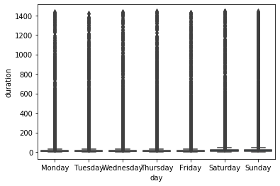

```python
sns.boxplot(df.day, df.duration, color=color);
```

As we remember from the distribution of duration values, great percentage of the values lie between 0 and 100 minutes, so let’s add these limits so the outliers can’t affect the visualization

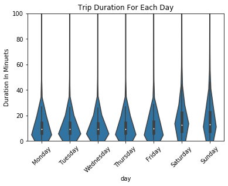

```python
sns.violinplot(df.day, df.duration, color=color)
plt.ylim(0, 100)
plt.title('trip duration for each day'.title())
plt.ylabel('Duration in minuets'.title())
plt.xticks(rotation=45);
```

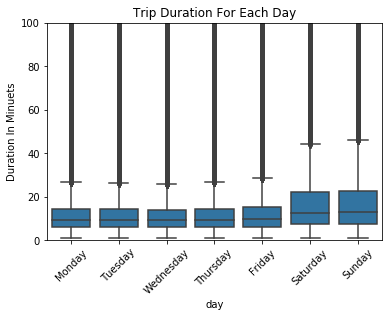

```python
sns.boxplot(df.day, df.duration, color=color)
plt.ylim(0, 100)
plt.title('trip duration for each day'.title())
plt.ylabel('Duration in minuets'.title())
plt.xticks(rotation=45);
```

The trip duration for each month

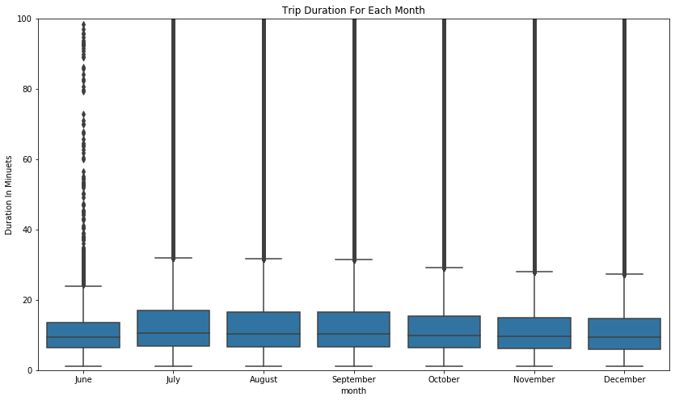

```python
plt.figure(figsize=(14, 8))
sns.boxplot(df.month, df.duration, color=color)
plt.ylim(0, 100)
plt.title('trip duration for each month'.title())
plt.ylabel('Duration in minuets'.title());
#plt.xticks(rotation=45);
```

### Talk about some of the relationships you observed in this part of the investigation. How did the feature(s) of interest vary with other features in the dataset?

> More people tend to ride in the weekday than in the weekends, but people tend to ride longer during the weekends.

## Multivariate Exploration

I would like to check the duration of rides and the user type per day.

```python
#first I would take a subset of the dataset where the duration is less than 100
df_sub = df[df.duration < 100]
df_sub.head()
```

|  | duration | start_time | end_time | start_station_id | start_station_name | start_station_latitude | start_station_longitude | end_station_id | end_station_name | end_station_latitude | end_station_longitude | bike_id | user_type | month | day |
| --- | --- | --- | --- | --- | --- | --- | --- | --- | --- | --- | --- | --- | --- | --- | --- |
| 6 | 75.12 | 2017-12-31 23:49:28.422 | 2018-01-01 01:04:35.619 | 259 | Addison St at Fourth St | 37.866249 | -122.299371 | 259 | Addison St at Fourth St | 37.866249 | -122.299371 | 3539 | Customer | December | Sunday |
| 7 | 72.23 | 2017-12-31 23:46:37.196 | 2018-01-01 00:58:51.211 | 284 | Yerba Buena Center for the Arts (Howard St at ... | 37.784872 | -122.400876 | 284 | Yerba Buena Center for the Arts (Howard St at ... | 37.784872 | -122.400876 | 1503 | Customer | December | Sunday |
| 8 | 69.17 | 2017-12-31 23:37:07.548 | 2018-01-01 00:46:18.308 | 20 | Mechanics Monument Plaza (Market St at Bush St) | 37.791300 | -122.399051 | 20 | Mechanics Monument Plaza (Market St at Bush St) | 37.791300 | -122.399051 | 3125 | Customer | December | Sunday |
| 9 | 70.63 | 2017-12-31 23:35:38.145 | 2018-01-01 00:46:17.053 | 20 | Mechanics Monument Plaza (Market St at Bush St) | 37.791300 | -122.399051 | 20 | Mechanics Monument Plaza (Market St at Bush St) | 37.791300 | -122.399051 | 2543 | Customer | December | Sunday |
| 10 | 54.87 | 2017-12-31 23:46:32.403 | 2018-01-01 00:41:24.605 | 284 | Yerba Buena Center for the Arts (Howard St at ... | 37.784872 | -122.400876 | 22 | Howard St at Beale St | 37.789756 | -122.394643 | 3058 | Customer | December | Sunday |

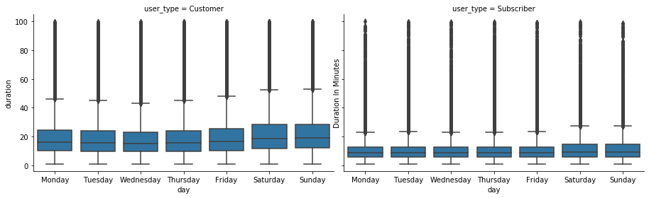

```python
#Plotting ride duration for each day per user type using FacetGrid
g = sns.FacetGrid(data=df_sub, col='user_type', aspect=1.6, height=4)
g.map(sns.boxplot, 'day', 'duration');
plt.ylabel('duration in minutes'.title());
```

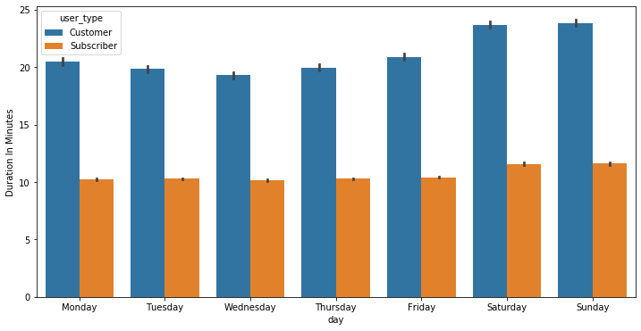

```python
#We can also have them in one plot using the hue function
plt.figure(figsize=(12, 6))
sns.barplot(df_sub.day, df_sub.duration, hue=df_sub.user_type)
plt.ylabel('duration in minutes'.title());
```

- Based on the above plots, we found out the subscribers tend to have far more trips but, in the meantime, they have shorter trips as it is clear that customers have longer durations for their trips.
- Both customers and subscribers tend to have longer trips during the weekends over the weekdays.